# Cox Survival Analysis for Medulloblastoma Samples

Run Jin

8/18/2021

## Import relevant data & select cohort of interest

```r
histology_df <- read_tsv("../data/histologies.tsv")
expression_data <- readRDS("../data/gene-expression-rsem-tpm-collapsed.rds")

cohort_df <- histology_df %>% dplyr::filter(tumor_descriptor == "Initial CNS Tumor") %>%
  dplyr::filter(experimental_strategy=="RNA-Seq") %>%
  dplyr::filter(cancer_group %in% c("Medulloblastoma"))

cohort_df$PFS_days <- as.numeric(cohort_df$PFS_days)
cohort_df <- cohort_df %>%
  dplyr::mutate(PFS_status = if_else(PFS_days < OS_days, 1, 0)) %>%
  dplyr::select(Kids_First_Biospecimen_ID, OS_status, OS_days, PFS_status, PFS_days, harmonized_diagnosis, CNS_region)

nrow(cohort_df)
```

```
## [1] 108
```

```r
cohort_df
```

```
## # A tibble: 108 × 7
##    Kids_First_Biospecimen_ID OS_status OS_days PFS_status PFS_days harmonized_diag…
##    <chr>                     <chr>       <dbl>      <dbl>    <dbl> <chr>
##  1 BS_1AYRM596               LIVING        567          0      567 Medulloblastoma…
##  2 BS_1BWP5MCT               DECEASED      599          1      384 Medulloblastoma
##  3 BS_1TWCV047               LIVING       1782          0     1782 Medulloblastoma
##  4 BS_2SFTWNVE               LIVING         NA         NA       NA Medulloblastoma
##  5 BS_2Z1MKS84               LIVING        579          0      579 Medulloblastoma…
##  6 BS_3F5PR9GS               LIVING       3337          0     3337 Medulloblastoma…
##  7 BS_3MYEMXPQ               LIVING       1809          0     1809 Medulloblastoma…
##  8 BS_3NWQXPQV               LIVING       2581          1     1049 Medulloblastoma…
##  9 BS_3V3KE3VT               LIVING        107          0      107 Medulloblastoma…
## 10 BS_44A3ES23               LIVING        107          0      107 Medulloblastoma…
## # … with 98 more rows, and 1 more variable: CNS_region <chr>
```

Define directory

```r
# create directory
root_dir <- rprojroot::find_root(rprojroot::has_dir(".git"))

coxph_train_results_dir <- file.path(root_dir, "molecular_target_radiation", "results", "Medulloblastoma", "coxph_survival_train")

coxph_test_results_dir <- file.path(root_dir, "molecular_target_radiation", "results","Medulloblastoma", "coxph_survival_test")

cox_survival_plots_dir <- file.path(root_dir, "molecular_target_radiation", "plots","Medulloblastoma", "CoxPH_survival")

if (!dir.exists(coxph_train_results_dir )) {
  dir.create(coxph_train_results_dir , recursive = TRUE)
}

if (!dir.exists(coxph_test_results_dir )) {
  dir.create(coxph_test_results_dir , recursive = TRUE)
}

if (!dir.exists(cox_survival_plots_dir )) {
  dir.create(cox_survival_plots_dir , recursive = TRUE)
}
```

## Merge expression data to histology file

```r
# get biospecimen ID's for samples
cohort_bsid <- cohort_df %>% pull(Kids_First_Biospecimen_ID) %>% unique()

# subset to gene and sample of interest
expression_of_interest <- expression_data %>% dplyr::select(all_of(cohort_bsid)) %>%
  rownames_to_column("GeneSymbol") %>%
  dplyr::filter(GeneSymbol %in% c("SLC7A5", "FOLH1")) %>%
  column_to_rownames("GeneSymbol") %>%
  t() %>% as.data.frame() %>%
  rownames_to_column("Kids_First_Biospecimen_ID")

#annotate relevant clinical information to the expression data frame
combined <- expression_of_interest %>% dplyr::left_join(cohort_df)
```

## Modify histology file to mark living as 0 and deceased as 1

```r
combined_annotated <- combined %>% dplyr::filter(!is.na(OS_status)) %>%
  dplyr::mutate(os_status_level = case_when(
    OS_status == "LIVING" ~ 0,
    OS_status == "DECEASED" ~ 1
  ))

# change the columns to desired type
combined_annotated$harmonized_diagnosis <- as.factor(combined_annotated$harmonized_diagnosis)
combined_annotated$CNS_region <- as.factor(combined_annotated$CNS_region)

#the number of samples that HAVE OS_status is:
nrow(combined_annotated)
```

```
## [1] 105
```

## Build up the model for cox analysis below

```r
model_slc7a5 <- as.formula(survival::Surv(OS_days, os_status_level) ~ harmonized_diagnosis + CNS_region + SLC7A5)
model_folh1 <- as.formula(survival::Surv(OS_days, os_status_level) ~ harmonized_diagnosis + CNS_region + FOLH1)
```

## Create train test partition

```r
set.seed(236)
trainIndex <- createDataPartition(combined_annotated$OS_status, p = 0.6,
                                      list = FALSE,
                                      times = 1)
data_train <- combined_annotated[trainIndex, ]
data_test <- combined_annotated[-trainIndex, ]
```

## Run Cox Analysis on training set

First run it for SLC7A5

```r
coxph_train_slc7a5 <- survival::coxph(model_slc7a5,
                     data = data_train)
coxph_train_slc7a5_sum <- as.data.frame(summary(coxph_train_slc7a5)$coefficients, keep.rownames = T) %>%
  tibble::rownames_to_column()
coxph_train_slc7a5_sum %>% knitr::kable()
```

| rowname | coef | exp(coef) | se(coef) | z | Pr(>\|z\|) |
| --- | --- | --- | --- | --- | --- |
| harmonized_diagnosisMedulloblastoma, group 3 | -1.4419109 | 0.2364754 | 1.2453158 | -1.1578676 | 0.2469181 |
| harmonized_diagnosisMedulloblastoma, group 4 | -2.0124481 | 0.1336611 | 0.8197901 | -2.4548334 | 0.0140950 |
| harmonized_diagnosisMedulloblastoma, SHH-activated | -0.7872119 | 0.4551119 | 0.6512717 | -1.2087303 | 0.2267665 |
| harmonized_diagnosisMedulloblastoma, WNT-activated | -19.0625687 | 0.0000000 | 9488.1428460 | -0.0020091 | 0.9983970 |
| CNS_regionMixed | -1.2115516 | 0.2977349 | 1.0840088 | -1.1176584 | 0.2637129 |
| CNS_regionPosterior fossa | -2.3726208 | 0.0932361 | 0.9664956 | -2.4548699 | 0.0140936 |
| CNS_regionVentricles | NA | NA | 0.0000000 | NA | NA |
| SLC7A5 | 0.0250512 | 1.0253676 | 0.0515696 | 0.4857747 | 0.6271269 |

```r
coxph_train_results_os_dir <- file.path(coxph_train_results_dir, "OS")

if (!dir.exists(coxph_train_results_os_dir )) {
  dir.create(coxph_train_results_os_dir , recursive = TRUE)
}

write_tsv(coxph_train_slc7a5_sum , file.path(coxph_train_results_os_dir, "coxph_train_slc7a5_sum.tsv"))
```

Then run it for FOLH1

```r
coxph_train_folh1 <- survival::coxph(model_folh1,
                     data = data_train)
coxph_train_folh1_sum <- as.data.frame(summary(coxph_train_folh1)$coefficients, keep.rownames = T) %>%
  tibble::rownames_to_column()
coxph_train_folh1_sum %>% knitr::kable()
```

| rowname | coef | exp(coef) | se(coef) | z | Pr(>\|z\|) |
| --- | --- | --- | --- | --- | --- |
| harmonized_diagnosisMedulloblastoma, group 3 | -1.4776694 | 0.2281688 | 1.2340540 | -1.1974107 | 0.2311465 |
| harmonized_diagnosisMedulloblastoma, group 4 | -2.0845985 | 0.1243570 | 0.8030421 | -2.5958769 | 0.0094350 |
| harmonized_diagnosisMedulloblastoma, SHH-activated | -0.8186550 | 0.4410245 | 0.6453307 | -1.2685820 | 0.2045902 |
| harmonized_diagnosisMedulloblastoma, WNT-activated | -18.7822895 | 0.0000000 | 9506.2473573 | -0.0019758 | 0.9984236 |
| CNS_regionMixed | -1.0157999 | 0.3621126 | 1.3962228 | -0.7275343 | 0.4668987 |
| CNS_regionPosterior fossa | -2.0331527 | 0.1309221 | 1.4723228 | -1.3809150 | 0.1673051 |
| CNS_regionVentricles | NA | NA | 0.0000000 | NA | NA |
| FOLH1 | 0.3581568 | 1.4306899 | 1.0945046 | 0.3272319 | 0.7434925 |

```r
write_tsv(coxph_train_folh1_sum , file.path(coxph_train_results_os_dir,"coxph_train_folh1_sum.tsv"))
```

## Calculate risk score for training set and predict for test set

First calculate for SLC7A5

```r
train_risk_slc7a5 <- predict(coxph_train_slc7a5, type = "risk")
med_risk_slc7a5 <- median(train_risk_slc7a5)
med_risk_slc7a5
```

```
## [1] 0.038208
```

```r
test_risk_slc7a5 <- predict(coxph_train_slc7a5, newdata = data_test, type = "risk") %>%
  as.data.frame() %>% cbind(data_test) %>%
  dplyr::rename("RiskScore" = ".") %>%
  dplyr::mutate(RiskGroup = case_when(
    RiskScore > med_risk_slc7a5 ~ "High",
    RiskScore <= med_risk_slc7a5 ~ "Low"
  ))

test_risk_slc7a5$RiskGroup <- as.factor(test_risk_slc7a5$RiskGroup)
```

Then calculate for FOLH1

```r
train_risk_folh1 <- predict(coxph_train_folh1, type = "risk")
med_risk_folh1 <- median(train_risk_folh1)
med_risk_folh1
```

```
## [1] 0.05344068
```

```r
test_risk_folh1 <- predict(coxph_train_folh1, newdata = data_test, type = "risk") %>%
  as.data.frame() %>% cbind(data_test) %>%
  dplyr::rename("RiskScore" = ".") %>%
  dplyr::mutate(RiskGroup = case_when(
    RiskScore > med_risk_folh1 ~ "High",
    RiskScore <= med_risk_folh1 ~ "Low"
  ))

test_risk_folh1$RiskGroup <- as.factor(test_risk_folh1$RiskGroup)
```

## Now run Cox analyses per gene for RiskScore and RiskGroup

First calculate per risk group for SLC7A5

```r
coxph_riskgroup_slc7a5 <- survival::coxph(formula = Surv(OS_days, os_status_level) ~  RiskGroup,
                     data = test_risk_slc7a5)
coxph_riskgroup_slc7a5_sum <- as.data.frame(summary(coxph_riskgroup_slc7a5)$coefficients) %>%
  rownames_to_column()
coxph_riskgroup_slc7a5_sum %>% knitr::kable()
```

| rowname | coef | exp(coef) | se(coef) | z | Pr(>\|z\|) |
| --- | --- | --- | --- | --- | --- |
| RiskGroupLow | -0.7740071 | 0.4611614 | 0.7120778 | -1.08697 | 0.2770501 |

Calculate per risk score for SLC7A5

```r
coxph_riskscore_slc7a5 <- survival::coxph(formula = Surv(OS_days, os_status_level) ~  RiskScore,
                     data = test_risk_slc7a5)
coxph_riskscore_slc7a5_sum <- as.data.frame(summary(coxph_riskscore_slc7a5)$coefficients) %>%
  rownames_to_column()
coxph_riskscore_slc7a5_sum %>% knitr::kable()
```

| rowname | coef | exp(coef) | se(coef) | z | Pr(>\|z\|) |
| --- | --- | --- | --- | --- | --- |
| RiskScore | 12.2978 | 219213.1 | 4.968987 | 2.474911 | 0.013327 |

Saving results for SLC7A5 results:

```r
coxph_test_results_os_dir <- file.path(coxph_test_results_dir, "OS")

if (!dir.exists(coxph_test_results_os_dir )) {
  dir.create(coxph_test_results_os_dir , recursive = TRUE)
}

write_tsv(coxph_riskgroup_slc7a5_sum, file.path(coxph_test_results_os_dir, "coxph_test_riskgroup_slc7a5_sum.tsv"))
write_tsv(coxph_riskscore_slc7a5_sum, file.path(coxph_test_results_os_dir, "coxph_test_riskscore_slc7a5_sum.tsv"))
```

Then calculate per risk group for FOLH1

```r
coxph_riskgroup_folh1 <- survival::coxph(formula = Surv(OS_days, os_status_level) ~  RiskGroup,
                     data = test_risk_folh1)
coxph_riskgroup_folh1_sum <- as.data.frame(summary(coxph_riskgroup_folh1)$coefficients) %>%
  rownames_to_column()
coxph_riskgroup_folh1_sum %>% knitr::kable()
```

| rowname | coef | exp(coef) | se(coef) | z | Pr(>\|z\|) |
| --- | --- | --- | --- | --- | --- |
| RiskGroupLow | -1.330753 | 0.2642781 | 0.7336319 | -1.813925 | 0.0696893 |

Calculate per risk score for FOLH1

```r
coxph_riskscore_folh1 <- survival::coxph(formula = Surv(OS_days, os_status_level) ~  RiskScore,
                     data = test_risk_folh1)
coxph_riskscore_folh1_sum <- as.data.frame(summary(coxph_riskscore_folh1)$coefficients) %>%
  rownames_to_column()
coxph_riskscore_folh1_sum %>% knitr::kable()
```

| rowname | coef | exp(coef) | se(coef) | z | Pr(>\|z\|) |
| --- | --- | --- | --- | --- | --- |
| RiskScore | 15.69908 | 6576964 | 6.075516 | 2.583992 | 0.0097664 |

Saving results for FOLH1 results:

```r
write_tsv(coxph_riskgroup_folh1_sum, file.path(coxph_test_results_os_dir, "coxph_test_riskgroup_folh1_sum.tsv"))
write_tsv(coxph_riskscore_folh1_sum, file.path(coxph_test_results_os_dir, "coxph_test_riskscore_folh1_sum.tsv"))
```

## Finally plot the survival for each gene per risk group

First generate plot for SLC7A5

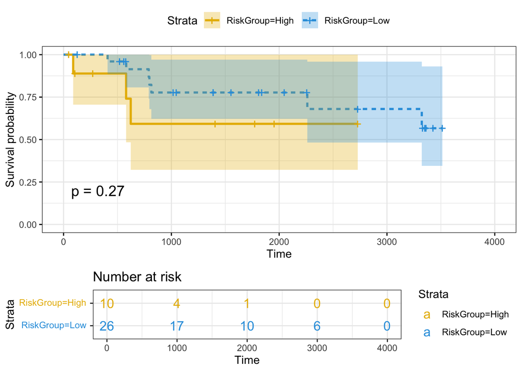

```r
fit_slc7c5 <- survfit(Surv(OS_days, os_status_level) ~ RiskGroup, data = test_risk_slc7a5)
plot_coxph_riskgroup_slc7a5 <- survminer::ggsurvplot(fit_slc7c5,
           data=test_risk_slc7a5,
           pval = TRUE,
           conf.int = TRUE,
           risk.table = TRUE, # Add risk table
           risk.table.col = "strata", # Change risk table color by groups
           linetype = "strata", # Change line type by groups
           surv.median.line = "hv", # Specify median survival
           ggtheme = theme_bw(), # Change ggplot2 theme
           palette = c("#E7B800", "#2E9FDF"))
# Make this plot a combined plot
surv_plot_slc7a5 <- cowplot::plot_grid(plot_coxph_riskgroup_slc7a5[[1]],
                                       plot_coxph_riskgroup_slc7a5[[2]],
                                       nrow = 2,
                                       rel_heights = c(2.5, 1))
# Print it out here
surv_plot_slc7a5
```

```r
cox_survival_plots_os_dir <- file.path(cox_survival_plots_dir, "OS")
if (!dir.exists(cox_survival_plots_os_dir )) {
  dir.create(cox_survival_plots_os_dir , recursive = TRUE)
}

# Save the plot
cowplot::save_plot(filename = file.path(cox_survival_plots_os_dir, "coxph_riskgroup_slc7a5_survival.png"), plot = surv_plot_slc7a5)
```

Second generate plot for FOLH1

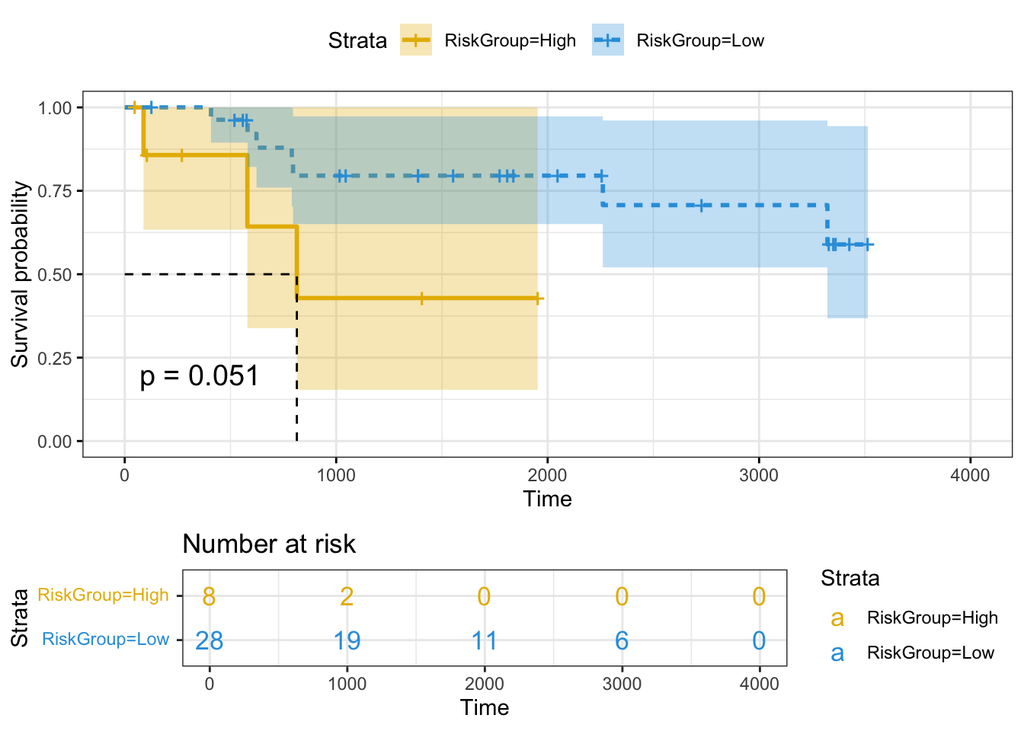

```r
fit_folh1 <- survfit(Surv(OS_days, os_status_level) ~ RiskGroup, data = test_risk_folh1)
plot_coxph_riskgroup_folh1 <- survminer::ggsurvplot(fit_folh1,
           data=test_risk_folh1,
           pval = TRUE,
           conf.int = TRUE,
           risk.table = TRUE, # Add risk table
           risk.table.col = "strata", # Change risk table color by groups
           linetype = "strata", # Change line type by groups
           surv.median.line = "hv", # Specify median survival
           ggtheme = theme_bw(), # Change ggplot2 theme
           palette = c("#E7B800", "#2E9FDF"))

# Make this plot a combined plot
surv_plot_folh1 <- cowplot::plot_grid(plot_coxph_riskgroup_folh1[[1]],
                                      plot_coxph_riskgroup_folh1[[2]],
                                      nrow = 2,
                                      rel_heights = c(2.5, 1))
# Print it out here
surv_plot_folh1
```

```r
# Save the plot
cowplot::save_plot(filename = file.path(cox_survival_plots_os_dir, "coxph_riskgroup_folh1_survival.png"), plot = surv_plot_folh1)
```